# print(‘Hello, Brazil!’) - Uma Análise Quantitativa da Posse de Bolsonaro

### Redes de Similaridade

Uma coisa importante a se questionar sobre um conjunto de textos é o grau de similaridade entre eles. O principal empecilho que surge ao abordar esse problema é o de como quantificar a similaridade entre dois documentos. Uma primeira ideia seria contabilizar o número de palavras compartilhadas pelos textos. Entretanto, acreditamos que essa idéia pode ser melhor aproveitada para conjuntos de documentos maiores e mais variados, pois no nosso caso, teríamos muita similaridade entre todos os textos devido à natureza da ocasião. Alternativamente, vamos considerar o nível de similaridade entre dois textos com a soma do TF-IDF das palavras que aparecem em ambos. Quanto mais alto é esse número, mais palavras importantes são compartilhadas pelos textos.

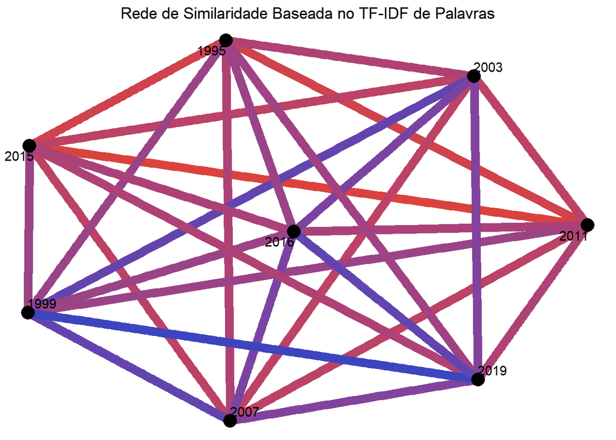

```r
## Via single words-docs##

## Cria data frame
textsimwdocs <- data.frame()

for (i in tfrases2$docs %>% unique()) {
  for (j in tfrases2$docs %>% unique()) {
    words1 <- (tfrases2 %>% filter(docs == i))$word %>% unique()
    words2 <- (tfrases2 %>% filter(docs == j))$word %>% unique()
    aux <- tfrases2 %>% filter(word %in% words1 && word %in% words2)
    num <- sum(aux$tf_idf)
    textsimwdocs <- rbind(textsimwdocs, c(i, j, num))
  }
}
colnames(textsimwdocs) <- c("x1", "x2", "sim")
textsimwdocs <- textsimwdocs %>% filter(textsimwdocs$x1 != textsimwdocs$x2)

## GRAFO

similarity_graphwdocs <- textsimwdocs %>%
  graph_from_data_frame() # From `igraph`

set.seed(1)

a <- grid::arrow(type = "closed", length = unit(.15, "inches"))

ggraph(similarity_graphwdocs, layout = "fr") +
  geom_edge_link(alpha = .8) +
  geom_edge_link(aes(edge_colour = (sim / 10000000), edge_width = 5)) +
  scale_edge_colour_gradient(
    low = "#3d45be", high = "#db423d",
    space = "Lab", na.value = "grey50", guide = "edge_colourbar"
  ) +
  geom_node_point(color = "black", size = 5) +
  geom_node_text(aes(label = name), repel = TRUE) +
  theme_void() + theme(
    legend.position = "none",
    plot.title = element_text(hjust = 0.5)
  ) +
  ggtitle("Rede de Similaridade Baseada no TF-IDF de Palavras")
```

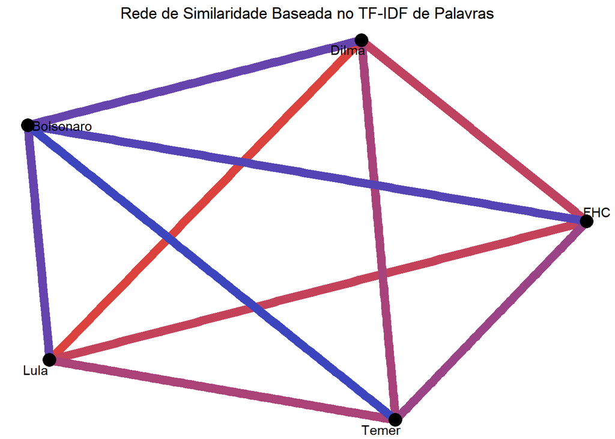

```r
## Via presidents
## Duplicar Temer e bonoro
tfrases <- tfrases %>%
  mutate(tf_idf = tf_idf + (presidas == "temer" | presidas == "bolsonaro") * tf_idf)


tfrases$presidas <- tfrases$presidas %>% as.character()

# Cria data frame
textsimwpres <- data.frame()
pr <- tfrases$presidas %>% unique()


for (i in 1:length(pr)) {
  for (j in 1:length(pr)) {
    words1 <- (tfrases %>% filter(presidas == pr[i]))$word %>% unique()
    words2 <- (tfrases %>% filter(presidas == pr[j]))$word %>% unique()
    aux <- tfrases %>% filter(word %in% words1 & word %in% words2)
    num <- sum(aux$tf_idf)
    textsimwpres <- rbind(textsimwpres, c(i, j, num))
  }
}

colnames(textsimwpres) <- c("x1", "x2", "sim")
textsimwpres <- textsimwpres %>% filter(textsimwpres[, 1] != textsimwpres[, 2])

# GRAFO

similarity_graphwpres <- textsimwpres %>%
  graph_from_data_frame() # From `igraph`

set.seed(1)

a <- grid::arrow(type = "closed", length = unit(.15, "inches"))

ggraph(similarity_graphwpres, layout = "fr") +
  geom_edge_link(alpha = .8) +
  geom_edge_link(aes(edge_colour = (sim / 10000), edge_width = 5)) +
  scale_edge_colour_gradient(
    low = "#3d45be", high = "#db423d",
    space = "Lab", na.value = "grey50", guide = "edge_colourbar"
  ) +
  geom_node_point(color = "black", size = 5) +
  geom_node_text(aes(label = c("Dilma", "Lula", "FHC", "Temer", "Bolsonaro")), repel = TRUE) +
  theme_void() + theme(
    legend.position = "none",
    plot.title = element_text(hjust = 0.5)
  ) +
  ggtitle("Rede de Similaridade Baseada no TF-IDF de Palavras")
```

Agora vamos experimentar fazer outras redes de similaridade, mas desta vez vamos partir do TF-IDF de bigramas que calculamos recentemente e aplicar exatamente os mesmos meios usados acima.

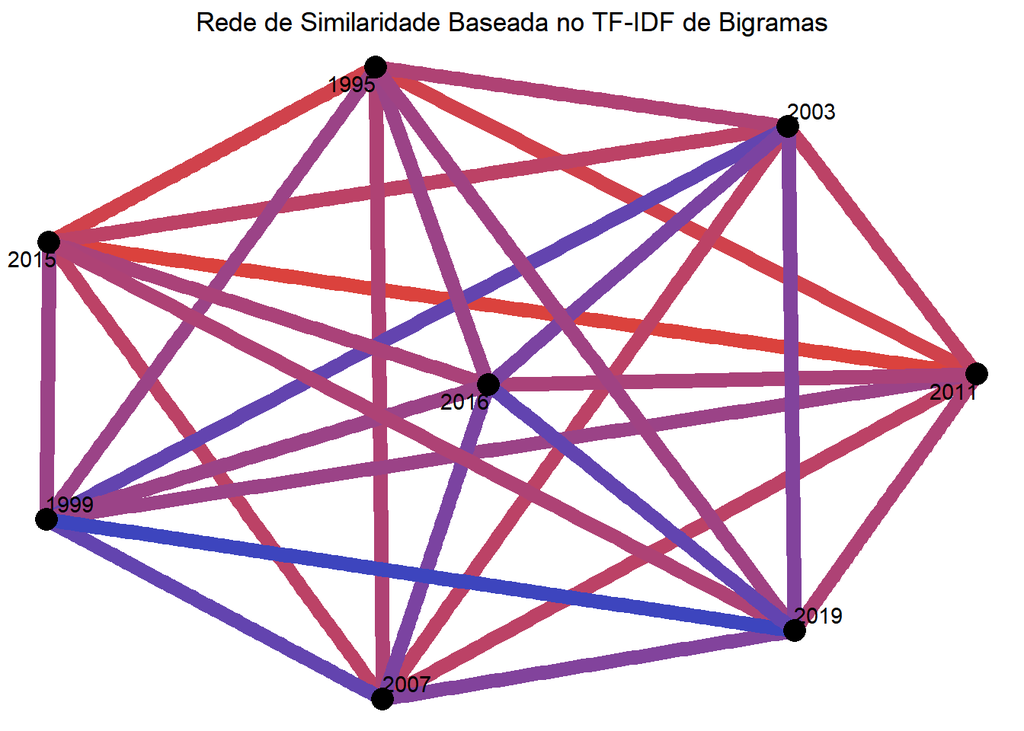

```r
# Similaridade Via Bigramas-Docs

textsimbdocs <- data.frame()

for (i in bigramsdoc_tdidf$docs %>% unique()) {
  for (j in bigramsdoc_tdidf$docs %>% unique()) {
    words1 <- (bigramsdoc_tdidf %>% filter(docs == i))$word %>% unique()
    words2 <- (bigramsdoc_tdidf %>% filter(docs == j))$word %>% unique()
    aux <- bigramsdoc_tdidf %>% filter(word %in% words1 && word %in% words2)
    num <- sum(aux$tf_idf)
    textsimbdocs <- rbind(textsimwdocs, c(i, j, num))
  }
}

colnames(textsimbdocs) <- c("x1", "x2", "sim")
textsimbdocs <- textsimbdocs %>% filter(textsimbdocs$x1 != textsimbdocs$x2)

similarity_graphbdocs <- textsimbdocs %>%
  graph_from_data_frame() # From `igraph`

set.seed(1)

a <- grid::arrow(type = "closed", length = unit(.15, "inches"))

ggraph(similarity_graphbdocs, layout = "fr") +
  geom_edge_link(alpha = .8) +
  geom_edge_link(aes(edge_colour = (sim / 10000000), edge_width = 5)) +
  scale_edge_colour_gradient(
    low = "#3d45be", high = "#db423d",
    space = "Lab", na.value = "grey50", guide = "edge_colourbar"
  ) +
  geom_node_point(color = "black", size = 5) +
  geom_node_text(aes(label = name), repel = TRUE) +
  theme_void() + theme(
    legend.position = "none",
    plot.title = element_text(hjust = 0.5)
  ) +
  ggtitle("Rede de Similaridade Baseada no TF-IDF de Bigramas")
```

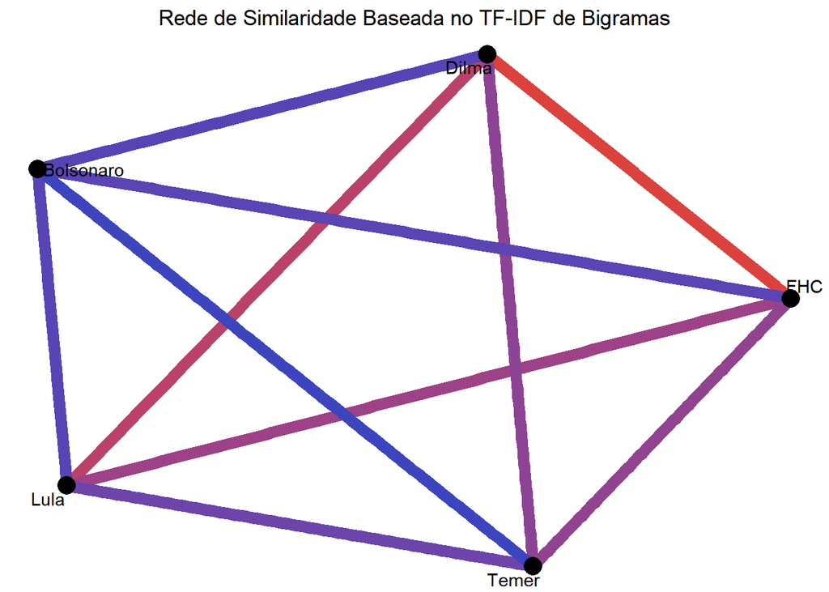

```r
## Via presidents

bigramspres_tdidf <- bigramspres_tdidf %>%
  mutate(tf_idf = tf_idf + (presidas == "temer" | presidas == "bolsonaro") * tf_idf)


bigramspres_tdidf$presidas <- bigramspres_tdidf$presidas %>% as.character()
textsimbpres <- data.frame()
prb <- bigramspres_tdidf$presidas %>% unique()


for (i in 1:length(prb)) {
  for (j in 1:length(prb)) {
    words1 <- (bigramspres_tdidf %>% filter(presidas == prb[i]))$word %>% unique()
    words2 <- (bigramspres_tdidf %>% filter(presidas == prb[j]))$word %>% unique()
    aux <- bigramspres_tdidf %>% filter(word %in% words1 & word %in% words2)
    num <- sum(aux$tf_idf)
    textsimbpres <- rbind(textsimbpres, c(i, j, num))
  }
}

colnames(textsimbpres) <- c("x1", "x2", "sim")
textsimbpres <- textsimbpres %>% filter(textsimbpres[, 1] != textsimbpres[, 2])




similarity_graphbpres <- textsimbpres %>%
  graph_from_data_frame() # From `igraph`

set.seed(1)

a <- grid::arrow(type = "closed", length = unit(.15, "inches"))

ggraph(similarity_graphbpres, layout = "fr") +
  geom_edge_link(alpha = .8) +
  geom_edge_link(aes(edge_colour = (sim / 10000), edge_width = 5)) +
  scale_edge_colour_gradient(
    low = "#3d45be", high = "#db423d",
    space = "Lab", na.value = "grey50", guide = "edge_colourbar"
  ) +
  geom_node_point(color = "black", size = 5) +
  geom_node_text(aes(label = c("Dilma", "Lula", "FHC", "Temer", "Bolsonaro")), repel = TRUE) +
  theme_void() + theme(
    legend.position = "none",
    plot.title = element_text(hjust = 0.5)
  ) +
  ggtitle("Rede de Similaridade Baseada no TF-IDF de Bigramas")
```

## Considerações Finais

A única constante no universo é a mudança. Ou seja, esse texto pode ser editado/ampliado a qualquer momento. Pedimos ao leitor que nos envie dúvidas, críticas e/ou sugestões para seguirmos melhorando. Neso se [link](https://github.com/aserranoni/possedobonoro) você pode encontrar o código, dados e imagens que utilizamos aqui. Obrigado por ter lido!

Ariel

Wilson